# act_report

## Report: act_report

- Create a **250-word-minimum written report** called "act_report.pdf" or "act_report.html" that communicates the insights and displays the visualization(s) produced from your wrangled data. This is to be framed as an external document, like a blog post or magazine article, for example.

### Report: Act_report by Sang Nguyen Trong

### Information about WeRateDogs

[figure not shown]

WeRateDogs is a renowned Twitter account that assigns ratings and provides amusing comments on people's pet dogs. Users are encouraged to submit pictures of their dogs, which are then tweeted by WeRateDogs along with a rating and humorous commentary. The ratings given to the dogs on a scale of one to ten always exceed the limit, such as 11/10, 12/10, 13/10, and so on. While these ratings may seem illogical, they serve a purpose. When questioned about their rating system, the Twitter user @dog_rates responded with the statement, "Pawan, they're astonishing dogs." This remark gained widespread attention, contributing to WeRateDogs' popularity in the international media and also highlighting social media copyright laws.

WeRateDogs was established in 2015 by Matt Nelson, a college student. As of November 2022, the Twitter account had amassed a following of approximately 9.3 million people. The account's distinct rating system, which exaggerates the ratings for dogs, has played a significant role in its success and widespread appeal.

[figure not shown]

I came across this amazing tweet with a 13/10 rating featuring a super adorable dog named Rupert. It's just too cute! As someone who loves thought-provoking tweets, I started pondering about the most frequently mentioned dog breeds on Twitter. I'm curious to know what their typical ratings are. Additionally, I also want to find out which stage of dogs appears most frequently in tweets. These questions will be the focus of my analysis for a project I'm working on.

### 1. Which dog breeds are the most popular?

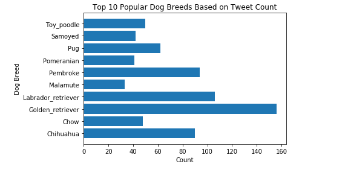

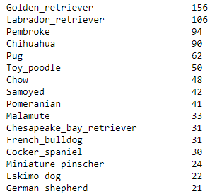

### Insight 1:

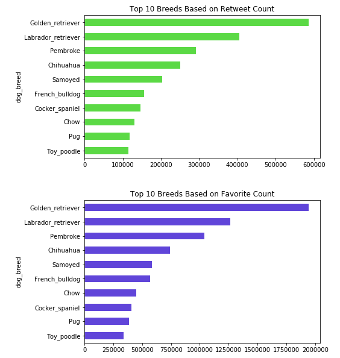

### Insight 2:

Overall, the three bar graphs reveal a consistent pattern, indicating that the most popular dog breeds in terms of both retweets and favorites are Golden Retrievers, Labrador Retrievers, Pembroke, and Chihuahuas. Among these, Golden Retrievers rank 1st in both retweet and favorite counts.

### 2. Based on the quantity of tweets, what are the popular breeds' average ratings?

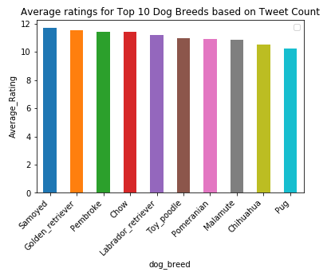

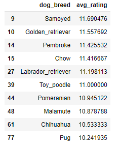

### Insight 3:

From the above data we can depict that there is very few difference between the rating of all the breeds

### 3. What phase of a dog is most typical?

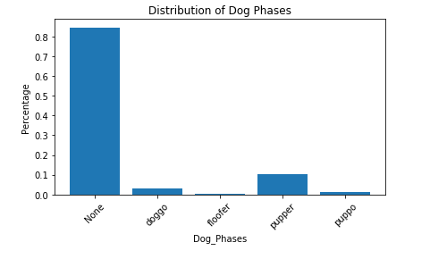

### Insight 4:

The bar chart indicates that over 80% of the tweets analyzed lack information about the dog's phase or stage mentioned in the article. Among the tweets that do provide phase information, the most frequent phase mentioned is "pupper" for individual dogs.